# Module format Parquet

Apprendre à utiliser des fichiers au format Parquet avec R

SSP/DEMESIS

22/12/2025

## 0.1 Avant-propos

Ce support ne couvre pas tous les aspects des traitements qu’il est possible de réaliser avec les fichiers au format Parquet mais il constitue une base sur laquelle s’appuyer si vous rencontrez des fichiers Parquet sur Cerise ou ailleurs.

# 1 C’est quoi un fichier parquet ?

## 1.1 C’est quoi le format Parquet ?

- Un nouveau format de données …
  - … qui compresse efficacement les fichiers
  - … interopérable
  - conçu pour que les données soient chargées rapidement en mémoire

## 1.2 Caractéristiques du format Parquet

- Un stockage au format binaire (pas lisible par un humain)
- Un stockage orienté colonne (par opposition aux csv qui sont orientés lignes)
- Un fichier Parquet contient à la fois les données et des métadonnées

```r
read_parquet("data/output.parquet", as_data_frame = FALSE)$schema

# > Table
# 3 rows x 4 columns
# $colonne1 <double not null>
# $colonne2 <string not null>
# $colonne3 <bool not null>
# $colonne4 <date32[day] not null>

read_parquet("data/output.parquet", as_data_frame = FALSE)$schema$metadata

# $auteur
# [1] "DEMESIS/BQIS"

# $description
# [1] "Table test de formation"

# $date_creation
# [1] "2025-01-22"
```

## 1.3 Avantages du format Parquet

- **Des fichiers moins volumineux qu’en csv** 500 Mo en Parquet vs 5 Go en csv
- **Des requêtes plus rapides et efficaces**  
  Seulement les données nécessaires sont lues, pas tout le fichier
- Des données conformes à la mise à disposition par le producteur (par exemple, plus de problème de codes communes…)  
  => Un format **très efficace pour l’analyse de données** mais **peu adapté à l’ajout de données en continu** ou **à la modification fréquente de données existantes**.

## 1.4 Un format qui se démocratise

- L’Insee diffuse des données du [recensement de la population](https://www.insee.fr/fr/statistiques/7637890#consulter-sommaire) au format Parquet
- Voir [le guide d’utilisation joint](https://ssphub.netlify.app/post/parquetrp/) pour manipuler ces données
- Premières diffusions sur [data.gouv](https://www.data.gouv.fr/fr/) avec les bureaux de vote, les demandes de valeurs foncières, indicateurs pénaux…)
- Prévisualisations des fichiers Parquet possibles avec le nouvel explorateur de données du SSP Cloud ou avec avec l’outil ParquetViewer.

## 1.5 Constitution d’un fichier parquet (1/3)

Un stockage en mode colonne :

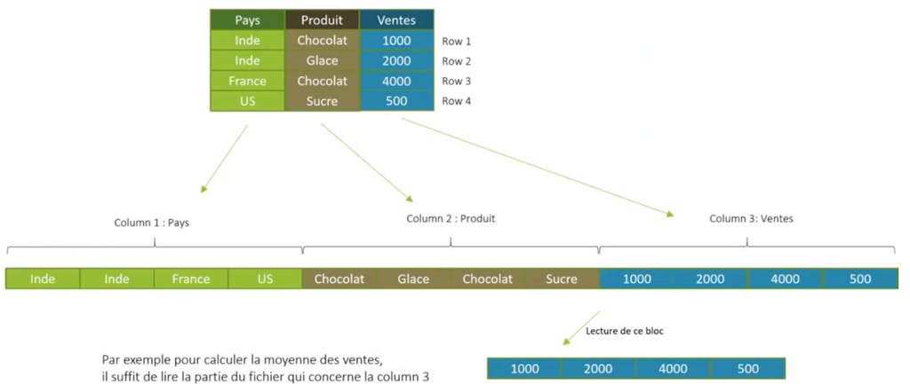

## 1.6 Constitution d’un fichier parquet (2/3)

Pour les gros fichiers, Parquet dispose les données dans des Row Groups.

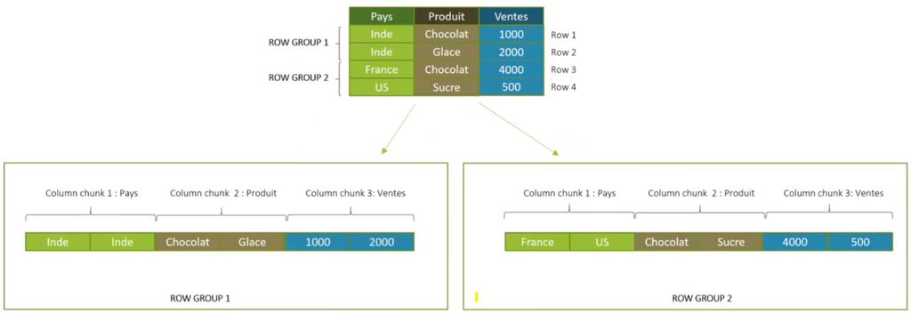

## 1.7 Constitution d’un fichier parquet (3/3)

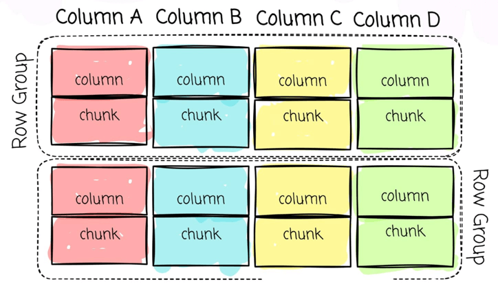

*Source : [voir ici](https://luminousmen.com/post/why-parquet-is-the-goto-format-for-data-engineers/)

Un fichier Parquet est organisé en `row groups` (groupes de lignes de 128 Mo par défaut) :

```
Chaque `row group` contient l’ensemble des colonnes du jeu de données.
```

Les données de chaque colonne sont stockées de manière colonnaire au sein du row group :

```
Chaque colonne est subdivisée en chunks (morceaux) stockés séquentiellement.
```

Cette structuration permet :

```
- Une lecture sélective efficace (on peut charger uniquement les colonnes nécessaires).

- Une compression optimisée, car les données similaires sont regroupées.

- Une excellente performance pour les requêtes analytiques sur de grands volumes.
```

# 2 Comment utiliser/interroger un fichier parquet ?

## 2.1 Lire un fichier avec read_parquet()

```r
library(arrow)    # Le package arrow est nécessaire pour travailler avec des fichiers parquet
library(dplyr)    # Pour utiliser dplyr
library(tictoc)   # Pour le benchmark
```

```r
tic()
RA2020 <- arrow::read_parquet("data/RA2020_exploitations.parquet")
toc()
> 1.14 sec elapsed
```

Le résultat obtenu est un objet directement utilisable dans R (ici un data.frame).

Il est possible de sélectionner les colonnes que l’on souhaite importer dans R directement dans la fonction `read_parquet` :

```r
tic()
RA2020_extrait <- arrow::read_parquet("data/RA2020_exploitations.parquet",
                                      col_select = c("NOM_DOSSIER","SIEGE_REG","SAU_TOT"))
toc()
> 0.06 sec elapsed
```

## 2.2 Comparaison avec la lecture d’un fichier rds

Voyons l’écart avec la lecture d’un fichier rds :

```r
tic()
RA2020 <- readRDS("data/RA2020_exploitations.rds")
toc()
> 6.15 sec elapsed
```

## 2.3 Des requêtes avec dplyr comme d’habitude

RA2020 est un data.frame : on peut donc utiliser la syntaxe dplyr :

```r
resultat <- RA2020 |>
  filter(SIEGE_REG == "93") |>
  group_by(SIEGE_DEP) |>
  summarise(total_SAU = sum(SAU_TOT, na.rm = TRUE))

# A tibble: 6 × 2
  SIEGE_DEP total_SAU
  <chr>         <dbl>
1 04          158946.
2 05           91979.
3 06           41141.
4 13          145713.
5 83           77785.
6 84          112888.
```

- Le temps d’exécution de la requête est d’environ 9 secondes.
- Les ressources consommées sont importantes

[figure not shown]

## 2.4 Lire et exploiter un fichier parquet volumineux

Voici ci-dessous la syntaxe recommandée pour requêter un fichier parquet volumineux :

```r
# Établir la connexion aux données
RA2020 <- open_dataset("data/RA2020_exploitations.parquet")  |>
  filter(SIEGE_REG == "93") |>
  group_by(SIEGE_DEP) |>
  summarise(total_SAU = sum(SAU_TOT, na.rm = TRUE)) |>
  collect()
```

=> Avec cette syntaxe, la requête va automatiquement utiliser les variables du fichier Parquet dont elle a besoin (en l’occurrence SIEGE_REG, SIEGE_DEP et SAU_TOT) et minimiser l’occupation de la mémoire vive.

Revenons dans le détail sur cette syntaxe…

## 2.5 La fonction `open_dataset()` (1/4)

Comme la fonction `read_parquet()`, la fonction `open_dataset()` permet de lire des données stockées en format Parquet.

```r
RA2020 <- open_dataset("data/RA2020_exploitations.parquet")

class(RA2020)

> [1] "FileSystemDataset" "Dataset" "ArrowObject" "R6"
```

## 2.6 La fonction `open_dataset()` (2/4)

La fonction `open_dataset()` crée un objet qui apparaît dans Values.

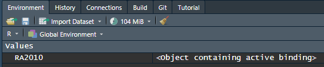

L’affichage dans la console d’un Arrow Table affiche uniquement quelques informations.

```r
RA2020

> FileSystemDataset with 1 Parquet file
NOM_DOSSIER: string
TYPE_QUESTIONNAIRE: string
SEUIL_IFS: string
CHAMP_GEO: string
COEF_F: double
NUMSTRATE: string
STRATE: string
SIEGENAT: string
SIEGE_CODE_COM: string
SIEGE_LIEUDIT: string
SIEGE_LIEUDIT_CODE_DOM: string
SIEGE_LIB_COM: string
...
```

## 2.7 La fonction `open_dataset()` (3/4)

Pour afficher le contenu d’un **Arrow Table**, il faut d’abord le convertir en data.frame avec la fonction `collect()`.

```r
RA2020 <- RA2020 |> collect()

class(RA2020)

> [1] "data.frame"

# L'opération ci-dessus est à éviter pour des tables volumineuses, si besoin de visualiser la table, on préfèrera :

extrait_RA2020 <- RA2020 |> slice_head(n = 100) |> collect()
```

Toutefois **rien ne presse** car la grande différence entre manipuler un data.frame et un Arrow Table tient **au moteur d’exécution** :

- Si on manipule un data.frame avec la syntaxe de dplyr, alors c’est le **moteur d’exécution de dplyr** qui fait les calculs
- Si on manipule un Arrow Table avec la syntaxe de dplyr, alors c’est le **moteur d’exécution d’arrow** (nommé **acero**) qui fait les calculs. Et le moteur d’exécution d’arrow est beaucoup plus efficace et rapide

## 2.8 La fonction `open_dataset()` (4/4)

Il est recommandé de privilégier la fonction `open_dataset()` à la fonction `read_parquet()` pour au moins 2 raisons :

- `open_dataset()` crée une connexion au fichier Parquet mais elle n’importe pas les données contenues dans ce fichier => **une consommation de RAM moins importante !**
- `open_dataset()` peut se connecter à un fichier Parquet unique mais aussi à des **fichiers Parquets partitionnés** (voir plus loin)

## 2.9 Consulter les métadonnées d’un fichier Parquet (1/4)

Pour obtenir des informations générales sur le fichier (par exemple titre, auteur, date…), il faut utiliser la fonction `read_parquet()` avec l’argument `as_data_frame = FALSE` pour pouvoir accéder aux métadonnées globales via `$schema$metadata`.

```r
# Lire le fichier Parquet en tant qu'Arrow Table avec read_parquet()
arrow_table <- arrow::read_parquet("output.parquet", as_data_frame = FALSE)

# Accéder aux métadonnées du fichier
arrow_table$schema$metadata
```

## 2.10 Consulter les métadonnées d’un fichier Parquet (2/4)

Le package [{nanoparquet}](https://nanoparquet.r-lib.org/index.html) permet aussi d’obtenir d’autres infos facilement depuis des fichiers parquet :

```r
library(nanoparquet)

read_parquet_info("data/RA2020_exploitations.parquet")

# > # A data frame: 1 × 7
  file_name                         num_cols num_rows num_row_groups file_size parquet_version created_by
  <chr>                                <int>    <dbl>          <int>     <dbl>           <int> <chr>
1 data/RA2020_exploitations.parquet      255   416478              1  39896331               2 parquet-cpp-arrow version 9.0.0
```

Le package [{parquetize}](https://ddotta.github.io/parquetize/) contient aussi des [fonctions similaires](https://ddotta.github.io/parquetize/reference/get_parquet_info.html) :

```r
library(parquetize)

get_parquet_info("data/RA2020_exploitations.parquet")

# > # A tibble: 1 × 5
  path                              num_rows num_row_groups num_columns mean_row_group_size
  <chr>                                <int>          <int>       <int>               <dbl>
1 data/RA2020_exploitations.parquet   416478              1         255              416478
```

## 2.11 Consulter les métadonnées d’un fichier Parquet (3/4)

- Les types des colonnes :

```r
nanoparquet::read_parquet_schema("data/output.parquet")

# A data frame: 4 × 6
# file_name    name     type       r_type    repetition_type logical_type
# * <chr>        <chr>    <chr>      <chr>     <chr>           <I<list>>
#   1 test.parquet colonne1 DOUBLE     double    REQUIRED        <NULL>
#   2 test.parquet colonne2 BYTE_ARRAY character REQUIRED        <STRING>
#   3 test.parquet colonne3 BOOLEAN    logical   REQUIRED        <NULL>
#   4 test.parquet colonne4 INT32      Date      REQUIRED        <DATE>
```

Attention, Parquet propose **2 niveaux de type** :  
- Le [bas niveau](https://parquet.apache.org/docs/file-format/types/)  
- Le [logical type](https://github.com/apache/parquet-format/blob/master/LogicalTypes.md)

## 2.12 Consulter les métadonnées d’un fichier Parquet (4/4)

La fonction `read_parquet_schema()` retourne les types de **bas niveau** dans la colonne `type` et les **logical_type** dans la colonne `logical_type`.

- Les types `bas niveau` : c’est la manière dont les données sont stockées physiquement dans le fichier.
- Les `logical types` : c’est une interprétation sémantique des données stockées (ils donnent du sens aux types bas niveau).

**Pour aller plus loin sur les métadonnées d’un fichier :**

```r
parquet_metadata("data/RA2020_exploitations.parquet")
```

*=> On obtient des informations sur le schéma, les row_groups, les column chunks…*

## 2.13 L’évaluation/exécution différée (1/4)

Cela signifie qu’**arrow** se contente de mémoriser les instructions, sans faire aucun calcul tant que l’utilisateur ne le demande pas explicitement.

Il existe **2 fonctions pour déclencher l’évaluation d’un traitement arrow** mais qui présente des différences :

- `collect()` qui renvoie le résultat du traitement sous la forme d’un **data.frame/tibble**
- `compute()` qui renvoie le résultat du traitement sous la forme d’un **Arrow Table**.

**La grande différence entre manipuler un tibble et manipuler un Arrow Table tient au** moteur d’exécution :

- Avec un **data.frame/tibble** => moteur d’exécution de dplyr
- Avec un **Arrow Table** => moteur d’exécution d’arrow (nommé acero) plus efficace que celui de dplyr

**Dans les traitements intermédiaires, on privilégiera la fonction `compute()` pour pouvoir utiliser le plus possible le moteur acero.**

## 2.14 L’évaluation/exécution différée (2/4)

```r
SAU_DEP <- RA2020 |>
  group_by(SIEGE_DEP) |>
  summarise(total_SAU = sum(SAU_TOT, na.rm = TRUE))
class(SAU_DEP)
> [1] "arrow_dplyr_query"

resultats <- SAU_DEP |>
  filter(SIEGE_DEP == "13") |>
  collect()
> # A tibble: 1 × 2
  SIEGE_DEP total_SAU
  <chr>         <dbl>
1 13          145713.
```

Dans l’exemple ci-dessus, **la première étape ne réalise aucun calcul par elle-même, car elle ne comprend ni collect() ni compute()**. L’objet `SAU_DEP` n’est pas une table et ne contient pas de données, il contient simplement une requête (query) décrivant les opérations à mener sur la table du RA.

arrow analyse la requête avant de l’exécuter, et optimise le traitement pour minimiser le travail.  
Dans notre exemple, arrow repère que la requête ne porte en fait que sur le département 13, et commence donc par filtrer les données sur le département avant de sommer la SAU les équipements, de façon à ne conserver que le minimum de données nécessaires et à ne réaliser que le minimum de calculs.

## 2.15 L’évaluation/exécution différée (3/4)

L’évaluation/exécution différée est très puissante mais **présente des limites**.

On serait tentés d’écrire un traitement entier *en mode lazy* (sans aucun `compute()` ni `collect()` dans les étapes intermédiaires) et de faire un unique `compute()` ou `collect()` tout à la fin du traitement afin que toutes les opérations soient optimisées en une seule étape.

Malheureusement, **le moteur acero** a ses limites notamment sur des traitements trop complexes (ce qui génère des plantages de sessions R).

## 2.16 L’évaluation/exécution différée (4/4)

**QUELQUES CONSEILS POUR ÉLABORER LA BONNE STRATÉGIE AVEC L’ÉVALUATION DIFFÉRÉE :**

- Décomposer le traitement en plusieurs étapes puis exécuter chaque étape séparément (avec un `compute()`)
- Définir la bonne longueur des étapes intermédiaires en gardant en tête :
  - D’avoir des étapes de traitement qui **ne dépassent pas 40 lignes de code**
  - Que le séquencement des étapes soit **cohérent** avec l’objet du traitement
  - Plus les **données sont volumineuses** OU les **opérations unitaires sont complexes**, plus **les étapes de traitement doivent être courtes/prudentes**

## 2.17 Quelques manques sur le moteur acero (1/2)

La liste des fonctions du *tidyverse* supportées par acero est disponible [sur cette page](https://arrow.apache.org/docs/dev/r/reference/acero.html).

Il y a (encore) quelques grands absents, notamment :

- `pivot_wider()` et `pivot_longer()` n’ont pas d’équivalent avec **acero**.
- **les empilements de plusieurs tables avec une seule fonction** (`bind_rows()` dans dplyr).  
  Avec des Arrow Tables, il faut appeler plusieurs fois ces fonctions (en l’occurence `union()`. Par exemple :

```r
resultats <- table1 |>
  union(table2) |>
  union(table3) |>
  compute()
```

## 2.18 Quelques manques sur le moteur acero (2/2)

- les *window functions* (ajouter à une table des informations issues d’une agrégation par groupe) comme par exemple :

```r
res <- RA2020 |>
  group_by(SIEGE_REG) |>
  mutate(total_SAU = sum(SAU_TOT)) |>
  collect()

> Error: window functions not currently supported in Arrow
Call collect() first to pull data into R.
```

Remarque : le code ci-dessus fonctionne par contre en remplaçant le `mutate()` par un `summarise()`.

## 2.19 Comment contourner le problème d’acero ? (1/3)

**Plusieurs solutions existent :**

1. Comme suggéré par R, renoncer à manipuler les données sous forme d’Arrow Table avec le moteur acero en passant par un `collect()` et poursuivre le traitement avec le moteur d’exécution de dplyr (avec des performances moins importantes).
2. Étudier le message d’erreur renvoyé par R et chercher à réécrire d’une autre façon le traitement.

## 2.20 Comment contourner le problème d’acero ? (2/3)

*Exemple pour le point 2 issu [d’utilitr](https://book.utilitr.org/) :*

```r
resultats <- bpe_ens_2018_arrow |>
  group_by(DEP) |>
  summarise(
    nb_boulangeries  = sum(NB_EQUIP * (TYPEQU == "B203")),
    nb_poissonneries = sum(NB_EQUIP * (TYPEQU == "B206"))
  ) |>
  compute()

> ! NotImplemented: Function 'multiply_checked' has no kernel matching input types (double, bool); pulling data into R
```

L’erreur vient de l’opération sum(NB_EQUIP * (TYPEQU == “B203”)) : **arrow** ne parvient pas à faire la multiplication entre NB_EQUIP (un nombre réel) et (TYPEQU == “B203”) (un booléen).

## 2.21 Comment contourner le problème d’acero ? (3/3)

=> La solution est très simple: **il suffit de convertir (TYPEQU == “B203”) en nombre entier avec la fonction as.integer() qui est supportée par acero**.

Le code suivant peut alors être entièrement exécuté par acero:

```r
resultats <- bpe_ens_2018_arrow |>
  group_by(DEP) |>
  summarise(
    nb_boulangeries  = sum(NB_EQUIP * as.integer(TYPEQU == "B203")),
    nb_poissonneries = sum(NB_EQUIP * as.integer(TYPEQU == "B206"))
  ) |>
  compute()
```

## 2.22 En conclusion sur le package arrow

**Le package arrow présente 3 avantages majeurs :**

- **Performances élevées** : arrow est très efficace et très rapide pour la manipulation de données tabulaires (nettement plus performant que dplyr par exemple)
- **Usage réduit des ressources** : arrow est conçu pour ne charger en mémoire que le minimum de données. Cela permet de réduire considérablement les besoins en mémoire, même lorsque les données sont volumineuses
- **Facilité d’apprentissage grâce aux approches dplyr et SQL**: arrow peut être utilisé avec les verbes de dplyr (select, mutate, etc.) et/ou avec le langage SQL grâce à DuckDB (voir plus loin).

## 2.23 Exercice 1

**Exercice 1 (premiers contacts avec un fichier parquet + rappels sur les fonctions)**

- Ouvrir le fichier parquet situé sous `~/CERISE/03-Espace-de-Diffusion/030_Structures_exploitations/3020_Recensements/RA_2020/01_BASES DIFFUSION RA2020/RA_2020_parquet/RA2020_EXPLOITATIONS_240112.parquet`
- Consulter les types de colonne de ce fichier
- Consulter les 100 premières lignes de ce fichier
- Récupérer dans un vecteur trié les codes régions des lieux principaux de production (SIEGE_REG)
- Récupérer dans un vecteur trié les libellés régions des lieux principaux de production (SIEGE_LIB_REG)
- Ecrire une fonction calculs_RA() qui - pour une région et une table donnée en entrée - conserve uniquement les lignes correspondantes selon la colonne SIEGE_REG, puis groupe la table par SIEGE_DEP et calcule la surface totale SAU (SAU_TOT), la surface totale de céréales (CEREALES_SUR_TOT) et la surface totale d’oléagineux (OLEAG_SUR_TOT) et enfin la part de la surface des céréales dans la SAU totale et la part de la surface des oléagineux dans la SAU totale.
- Utiliser ensuite la fonction calculs_RA() pour calculer ces indicateurs sur l’ensemble des régions présentes dans la table du RA2020 et stocker les résultats dans des fichiers Excel sous votre espace personnel.  
  *TIPS : pensez à utiliser {purrr} et {openxlsx} par exemple.*

## 2.24 Exercice 2

**Exercice 2 (`collect()` vs `compute()`)**

- Dans votre espace de travail, créer les 3 fichiers parquet suivants :

```r
data_a <- tibble(
  id = rep(1:1000000, each = 10),
  annee = rep(2016:2025, times = 1000000),
  a = sample(letters, 10000000, replace = TRUE)
)

data_b <- tibble(
  id = rep(1:1000000, each = 10),
  annee = rep(2016:2025, times = 1000000),
  b = runif(10000000, 1, 100)
)

data_c <- tibble(
  lettres = sample(letters, 10000000, replace = TRUE),
  classe = sample(c("pommes","poires","melon","fraise"), 10000000, replace = TRUE)
)

write_parquet(data_a, "data_a.parquet")
write_parquet(data_b, "data_b.parquet")
write_parquet(data_c, "data_c.parquet")

rm(data_a)
rm(data_b)
rm(data_c)
gc()
```

- La suite de l’exercice sur la slide suivante…

## 2.25 Exercice 2 (suite)

**Exercice 2 (`collect()` vs `compute()`)**

1. AVEC `collect()`

Charger les fichiers parquet `data_a` et `data_b`.  
Créer la table `etape1` en réalisant une jointure à gauche de `data_a` avec `data_b`.  
Charger le fichier parquet `data_c` sous forme de data.frame  
Filtrer la table `etape1` sur les années supérieures à 2020 puis faire la somme de la colonne `b` selon la colonne `a`  
Ajouter la colonne `classe` issue de la table `data_c` dans le tableau final.

2. AVEC `compute()`

Réaliser les mêmes traitements que A) avec des compute() et réduire le temps d’exécution.

# 3 Écrire des fichiers parquet

## 3.1 Données peu volumineuses: écrire un seul fichier Parquet (1/2)

En tant que responsable de sources, vous pouvez être amenés à écrire et déposer des fichiers Parquet, par exemple sous Cerise.

Pour cela, on utilise la fonction `write_parquet()`.  
Un 1er exemple simple à partir d’un fichier rds:

```r
# Lecture du fichier rds
msa_ns <- readRDS("data/msa_ns_src_2023.rds")

# Écriture des données en format Parquet
write_parquet(x = msa_ns, sink = "data/msa_ns_src_2023.parquet")
```

[figure not shown]

## 3.2 Données peu volumineuses: écrire un seul fichier Parquet (2/2)

Un autre exemple un peu plus compliqué à partir de fichier csv contenu dans un zip sur internet :

```r
# Chargement des packages
library(arrow)
library(readr)

# Téléchargement du fichier zip
download.file("https://www.insee.fr/fr/statistiques/fichier/2540004/dpt2021_csv.zip", destfile = "data/dpt2021_csv.zip")
# Décompression du fichier zip
unzip("data/dpt2021_csv.zip", exdir = "data")

# Lecture du fichier CSV
dpt2021 <- read_delim(file = "data/dpt2021.csv")

# Écriture des données en format Parquet
write_parquet(x = dpt2021, sink = "data/dpt2021.parquet"))
```

## 3.3 Données volumineuses: écrire un fichier Parquet partitionné (1/3)

**Pourquoi partitionner ?**

Par définition, il n’est pas possible de charger seulement quelques lignes d’un fichier Parquet : **on importe nécessairement des colonnes entières**.

Lorsque le fichier Parquet est partitionné, **arrow est capable de filtrer les lignes à importer à l’aide de clés de partitionnement**, ce qui permet d’accélérer l’importation des données.

**Le partitionnement permet de travailler sur des fichiers Parquet de plus petite taille et donc de consommer moins de mémoire vive.**

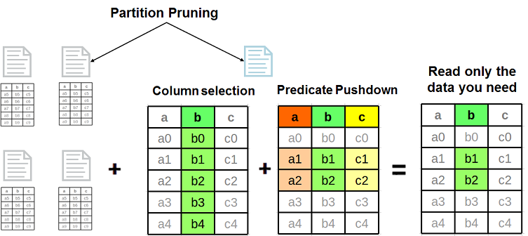

## 3.4 Données volumineuses: écrire un fichier Parquet partitionné (2/3)

Ça veut dire quoi partitionné ?

Partitionner un fichier revient à le “découper” selon une clé de partionnement (une ou plusieurs variables)

En pratique, l’ensemble des données sera stockée dans plusieurs fichiers au format Parquet.

Voici par exemple comment se présente un fichier Parquet partitionné selon les régions :

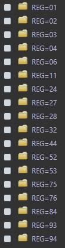

## 3.5 Données volumineuses: écrire un fichier Parquet partitionné (3/3)

**Pour écrire des fichiers Parquet partitionnés**, on utilise la fonction `write_dataset()`.

**Partitionnons** notre fichier issu de la MSA **par type d’exploitation et sexe** :

```r
write_dataset(
  dataset = msa_ns,
  path = "data/msa_ns",
  partitioning = c("TYPE_EXP","SEXE"), # les variables de partitionnement
  format = "parquet"
)
```

Voici un aperçu de l’arborescence créée (:

```r
data/msa_ns
├── TYPE_EXP=1
│   ├── SEXE=1
│   │   └── part-0.parquet
│   └── SEXE=2
│       └── part-0.parquet
├── TYPE_EXP=2
│   ├── SEXE=1
│   │   └── part-0.parquet
│   └── SEXE=2
│       └── part-0.parquet
└── TYPE_EXP=3
    ├── SEXE=1
    │   └── part-0.parquet
    └── SEXE=2
        └── part-0.parquet
```

## 3.6 Forcer les types des colonnes lors de l’écriture de fichiers Parquet

En tant que responsable de sources par exemple, vous pouvez forcer le typage des colonnes d’un fichier Parquet.  
Pour cela, assurez-vous que les colonnes du data.frame R sont au bon type.  
Si ce n’est pas le cas, utilisez les fonctions de conversion `as.character()`, `as.integer()`, `as.Date()` …

```r
#Créez un DataFrame R en spécifiant le type de chaque colonne
df <- data.frame(
  colonne1 = as.integer(c(1, 2, 3)),
  colonne2 = as.character(c("A", "B", "C")),
  colonne3 = as.logical(c(TRUE, FALSE, TRUE)),
  colonne4 = as.numeric(35.43, 29.93, 17.02))

write_parquet(table, "output.parquet")
```

Une autre façon de forcer le typage des colonnes est d’utiliser un `schema`. Cependant, cela apporte de la complexité au code pas forcément utile.  
En cas de besoin, un exemple est disponible sur [cette page](https://gist.github.com/ddotta/d3900a8c7d2d247a90de6f8c6a261172).